# # SICSS Norrköping 2023: Network Analysis (EXERCISE SHEET)

## Basic network descriptives

### Macro level (global level):

Summary statistics, such as - size, and average degree, degree distribution - average clustering - transitivity

#### Size and degrees

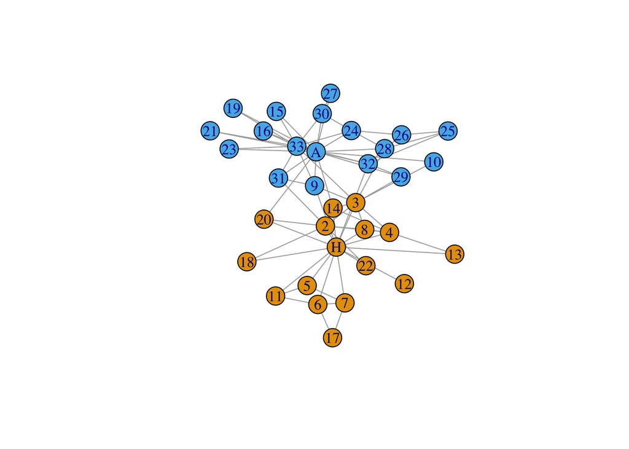

```r
data(karate) # data is loaded into a variable called karate

plot(karate)
```

```r
# number of nodes
V(karate)
```

```
## + 34/34 vertices, named, from 4b458a1:
##  [1] Mr Hi    Actor 2  Actor 3  Actor 4  Actor 5  Actor 6  Actor 7  Actor 8
##  [9] Actor 9  Actor 10 Actor 11 Actor 12 Actor 13 Actor 14 Actor 15 Actor 16
## [17] Actor 17 Actor 18 Actor 19 Actor 20 Actor 21 Actor 22 Actor 23 Actor 24
## [25] Actor 25 Actor 26 Actor 27 Actor 28 Actor 29 Actor 30 Actor 31 Actor 32
## [33] Actor 33 John A
```

```r
vcount(karate)
```

```
## [1] 34
```

```r
# number of edges
E(karate)
```

```
## + 78/78 edges from 4b458a1 (vertex names):
##  [1] Mr Hi  --Actor 2  Mr Hi  --Actor 3  Mr Hi  --Actor 4  Mr Hi  --Actor 5
##  [5] Mr Hi  --Actor 6  Mr Hi  --Actor 7  Mr Hi  --Actor 8  Mr Hi  --Actor 9
##  [9] Mr Hi  --Actor 11 Mr Hi  --Actor 12 Mr Hi  --Actor 13 Mr Hi  --Actor 14
## [13] Mr Hi  --Actor 18 Mr Hi  --Actor 20 Mr Hi  --Actor 22 Mr Hi  --Actor 32
## [17] Actor 2--Actor 3  Actor 2--Actor 4  Actor 2--Actor 8  Actor 2--Actor 14
## [21] Actor 2--Actor 18 Actor 2--Actor 20 Actor 2--Actor 22 Actor 2--Actor 31
## [25] Actor 3--Actor 4  Actor 3--Actor 8  Actor 3--Actor 9  Actor 3--Actor 10
## [29] Actor 3--Actor 14 Actor 3--Actor 28 Actor 3--Actor 29 Actor 3--Actor 33
## [33] Actor 4--Actor 8  Actor 4--Actor 13 Actor 4--Actor 14 Actor 5--Actor 7
## [37] Actor 5--Actor 11 Actor 6--Actor 7  Actor 6--Actor 11 Actor 6--Actor 17
## + ... omitted several edges
```

```r
ecount(karate)
```

```
## [1] 78
```

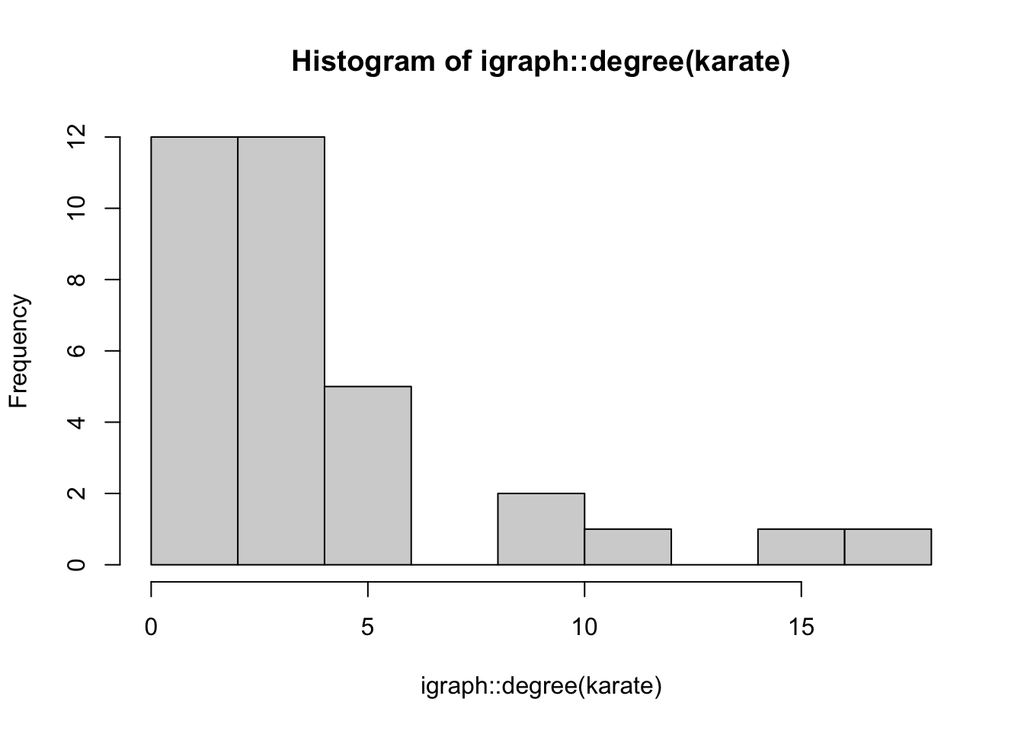

```r
# degrees
#igraph::degree(karate)

# degree distribution
hist(igraph::degree(karate))
```

#### Transitivity and average clustering coefficient

Often useful descriptives at the macro level is the transitivity coefficient and the average clustering coefficient (clustering coefficients also exist at the local (node-) level). Transitivity describes how many of the existing triads are actually closed. The average clustering coefficient describes – as the name already indicates – the average of all nodes’ clustering coefficient. The node-level clustering coefficient describes the fraction of possible triangles through a node that actually exists.

```r
adj_mtx_karate <- as.matrix(as_adj(karate, sparse = igraph_opt("sparsematrices"))) # convert igraph object to matrix (as sna package functions take matrices as input)

sna::isolates(adj_mtx_karate) # Check for isolates
```

```
## integer(0)
```

```r
sna::gden(adj_mtx_karate) # Density (Number of actual ties over Number of potential ties)
```

```
## [1] 0.1390374
```

```r
igraph::transitivity(karate, type = "average") # Transitivity (how many of existing relationship are closed (triangles))
```

```
## [1] 0.5879306
```

```r
mean(igraph::transitivity(karate, type = "local"), na.rm = TRUE) # average of the fractions of possible triangles through nodes that actually exists.
```

```
## [1] 0.5879306
```

```r
# Dyadic and triadic configurations
sna::dyad.census(adj_mtx_karate) # number of ties that are mutual, asymmetric, do not exist
```

```
##      Mut Asym Null
## [1,]  78    0  483
```

```r
sna::triad.census(adj_mtx_karate) # see: https://i.stack.imgur.com/9Xo0R.png
```

```
##       003 012  102 021D 021U 021C 111D 111U 030T 030C 201 120D 120U 120C 210
## [1,] 3971   0 1575    0    0    0    0    0    0    0 393    0    0    0   0
##      300
## [1,]  45
```

### Meso level (everything ‘in between’):

A group of nodes’ characteristics live at the mesoscale, such as - community detection - homophily - assortativity

#### Community detection

Community detection is a very large field of research and has received a lot of attention in the past. The wish behind community detection basically is to identify a network’s mesoscale organisation. In simplistic terms, a community is a group of nodes which are somewhat more related to each other than to others in the network. Community detection for networks is conceptually similar to data clustering in machine learning. It is helpful if one wants to find nodes that would, for example, react similarly to an external stimulus or if you want to visualize the meso-level organisation of a network.

There are many different algorithms out there to find communities: Some use a group’s internal density, the similarity to neighbours, or the idea of random walks, … As some of the approaches out there differ in their internal logic, they might yield slightly different results.

IGRAPH has some community detection algorithms built-in, which you can find [here](https://networkx.org/documentation/stable/reference/algorithms/community.html), and which we will use in the following.

```r
# GIRVAN-NEWMAN
# Partitioning is based on edge betweeness.
gn_clustering <- cluster_edge_betweenness(karate,modularity=TRUE,membership=TRUE)
gn_clustering
```

```
## IGRAPH clustering edge betweenness, groups: 6, mod: 0.35
## + groups:
##   $`1`
##   [1] "Mr Hi"    "Actor 2"  "Actor 4"  "Actor 8"  "Actor 12" "Actor 13"
##   [7] "Actor 18" "Actor 20" "Actor 22"
##
##   $`2`
##   [1] "Actor 3"  "Actor 10" "Actor 14" "Actor 29"
##
##   $`3`
##   [1] "Actor 5"  "Actor 6"  "Actor 7"  "Actor 11" "Actor 17"
##
##   + ... omitted several groups/vertices
```

```r
gn_clustering$modularity
```

```
##  [1] -0.0511047394 -0.0465508517 -0.0294409775 -0.0128558310 -0.0007215007
##  [6]  0.0181687000  0.0460073837  0.0582635258  0.0904031034  0.1027904275
## [11]  0.1135848279  0.1203875490  0.1422668241  0.1576151122  0.1643897228
## [16]  0.1765896441  0.1960045726  0.2127021608  0.2154569817  0.2289499822
## [21]  0.2412998257  0.2627480744  0.2777402972  0.2908959727  0.3056539420
## [26]  0.3154082570  0.3270272296  0.3366972133  0.3452990011  0.3266617942
## [31]  0.3187252863  0.3145462042  0.3092895560  0.0000000000
```

```r
# Communities are identified as components in the edge-pruned graph
# The partitioning where the modularity is the highest is the one that gets chosen at the end.

# WALKTRAP
# The walk trap algorithm is based on a series of short random walks.
# Random walks are hypothesized to stay within the same community.
walk_clustering <- cluster_walktrap(karate,step=10)
walk_clustering
```

```
## IGRAPH clustering walktrap, groups: 3, mod: 0.43
## + groups:
##   $`1`
##    [1] "Actor 9"  "Actor 10" "Actor 15" "Actor 16" "Actor 19" "Actor 21"
##    [7] "Actor 23" "Actor 24" "Actor 25" "Actor 26" "Actor 27" "Actor 28"
##   [13] "Actor 29" "Actor 30" "Actor 31" "Actor 32" "Actor 33" "John A"
##
##   $`2`
##    [1] "Mr Hi"    "Actor 2"  "Actor 3"  "Actor 4"  "Actor 8"  "Actor 12"
##    [7] "Actor 13" "Actor 14" "Actor 18" "Actor 20" "Actor 22"
##
##   $`3`
##   + ... omitted several groups/vertices
```

```r
# MOODY-WHITE
blocks_clustering <- cohesive_blocks(karate)
blocks_clustering$blocks
```

```
## [[1]]
## + 34/34 vertices, named, from 4b458a1:
##  [1] Mr Hi    Actor 2  Actor 3  Actor 4  Actor 5  Actor 6  Actor 7  Actor 8
##  [9] Actor 9  Actor 10 Actor 11 Actor 12 Actor 13 Actor 14 Actor 15 Actor 16
## [17] Actor 17 Actor 18 Actor 19 Actor 20 Actor 21 Actor 22 Actor 23 Actor 24
## [25] Actor 25 Actor 26 Actor 27 Actor 28 Actor 29 Actor 30 Actor 31 Actor 32
## [33] Actor 33 John A
##
## [[2]]
## + 28/34 vertices, named, from 4b458a1:
##  [1] Mr Hi    Actor 2  Actor 3  Actor 4  Actor 8  Actor 9  Actor 10 Actor 13
##  [9] Actor 14 Actor 15 Actor 16 Actor 18 Actor 19 Actor 20 Actor 21 Actor 22
## [17] Actor 23 Actor 24 Actor 25 Actor 26 Actor 27 Actor 28 Actor 29 Actor 30
## [25] Actor 31 Actor 32 Actor 33 John A
##
## [[3]]
## + 6/34 vertices, named, from 4b458a1:
## [1] Mr Hi    Actor 5  Actor 6  Actor 7  Actor 11 Actor 17
##
## [[4]]
## + 5/34 vertices, named, from 4b458a1:
## [1] Mr Hi   Actor 2 Actor 3 Actor 4 Actor 8
##
## [[5]]
## + 7/34 vertices, named, from 4b458a1:
## [1] Mr Hi    Actor 2  Actor 3  Actor 9  Actor 31 Actor 33 John A
##
## [[6]]
## + 5/34 vertices, named, from 4b458a1:
## [1] Mr Hi    Actor 5  Actor 6  Actor 7  Actor 11
##
## [[7]]
## + 5/34 vertices, named, from 4b458a1:
## [1] Mr Hi    Actor 2  Actor 3  Actor 4  Actor 14
##
## [[8]]
## + 10/34 vertices, named, from 4b458a1:
##  [1] Actor 3  Actor 24 Actor 25 Actor 26 Actor 28 Actor 29 Actor 30 Actor 32
##  [9] Actor 33 John A
```

```r
# Other clustering algorithms that you could use:
cluster_louvain(karate)
```

```
## IGRAPH clustering multi level, groups: 4, mod: 0.44
## + groups:
##   $`1`
##    [1] "Mr Hi"    "Actor 2"  "Actor 3"  "Actor 4"  "Actor 8"  "Actor 12"
##    [7] "Actor 13" "Actor 14" "Actor 18" "Actor 20" "Actor 22"
##
##   $`2`
##   [1] "Actor 5"  "Actor 6"  "Actor 7"  "Actor 11" "Actor 17"
##
##   $`3`
##    [1] "Actor 9"  "Actor 10" "Actor 15" "Actor 16" "Actor 19" "Actor 21"
##    [7] "Actor 23" "Actor 27" "Actor 30" "Actor 31" "Actor 33" "John A"
##   + ... omitted several groups/vertices
```

```r
cluster_fast_greedy(karate)
```

```
## IGRAPH clustering fast greedy, groups: 3, mod: 0.43
## + groups:
##   $`1`
##    [1] "Actor 9"  "Actor 10" "Actor 15" "Actor 16" "Actor 19" "Actor 21"
##    [7] "Actor 23" "Actor 24" "Actor 25" "Actor 26" "Actor 27" "Actor 28"
##   [13] "Actor 29" "Actor 30" "Actor 31" "Actor 32" "Actor 33" "John A"
##
##   $`2`
##    [1] "Mr Hi"    "Actor 2"  "Actor 3"  "Actor 4"  "Actor 8"  "Actor 12"
##    [7] "Actor 13" "Actor 14" "Actor 18" "Actor 20" "Actor 22"
##
##   $`3`
##   + ... omitted several groups/vertices
```

```r
cluster_leading_eigen(karate)
```

```
## IGRAPH clustering leading eigenvector, groups: 5, mod: 0.44
## + groups:
##   $`1`
##    [1] "Mr Hi"    "Actor 2"  "Actor 3"  "Actor 4"  "Actor 8"  "Actor 13"
##    [7] "Actor 14" "Actor 18" "Actor 20" "Actor 22"
##
##   $`2`
##    [1] "Actor 9"  "Actor 10" "Actor 15" "Actor 16" "Actor 19" "Actor 21"
##    [7] "Actor 23" "Actor 27" "Actor 30" "Actor 31" "Actor 33" "John A"
##
##   $`3`
##   [1] "Actor 5"  "Actor 6"  "Actor 7"  "Actor 11" "Actor 17"
##   + ... omitted several groups/vertices
```

```r
# How to extract the grouping
gn_clustering$membership
```

```
##  [1] 1 1 2 1 3 3 3 1 4 2 3 1 1 2 4 4 3 1 4 1 4 1 4 5 5 5 6 5 2 6 4 4 4 4
```

```r
V(karate)$gn_group <- as.factor(gn_clustering$membership)
V(karate)$wt_group <- as.factor(walk_clustering$membership)
V(karate)$fg_group <- as.factor(cluster_fast_greedy(karate)$membership)

V(karate)$fg_group
```

```
##  [1] 2 2 2 2 3 3 3 2 1 1 3 2 2 2 1 1 3 2 1 2 1 2 1 1 1 1 1 1 1 1 1 1 1 1
## Levels: 1 2 3
```

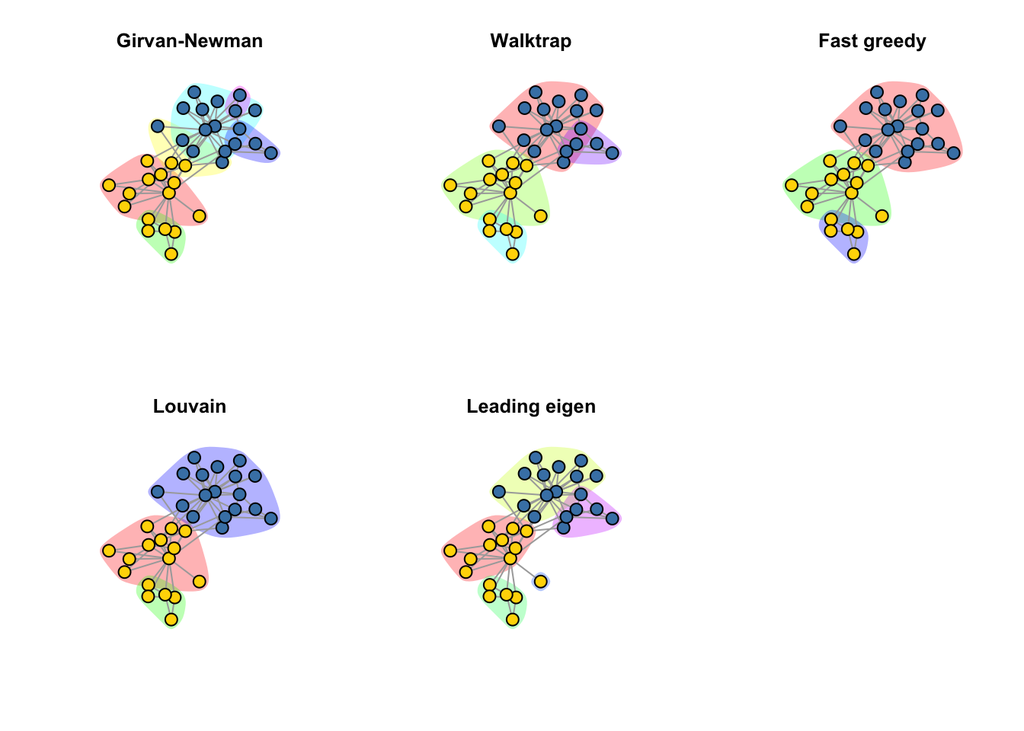

```r
# Add clustering to the visualisation
par(mfrow=c(2,3))
set_layout <- layout_with_fr(karate)

plot(karate,
     vertex.color = ifelse(V(karate)$color==1,'gold','steelblue'),
     #vertex.label = V(karate)$name,
     vertex.label = NA,
     main='Girvan-Newman',
     mark.groups = cluster_edge_betweenness(karate),
     mark.border=NA,
     layout = set_layout)
plot(karate,
     vertex.color = ifelse(V(karate)$color==1,'gold','steelblue'),
     #vertex.label = V(karate)$name,
     vertex.label = NA,
     main='Walktrap',
     mark.groups = cluster_walktrap(karate),
     mark.border=NA,
     layout = set_layout)

plot(karate,
     vertex.color = ifelse(V(karate)$color==1,'gold','steelblue'),
     #vertex.label = V(karate)$name,
     vertex.label = NA,
     main='Fast greedy',
     mark.groups = cluster_fast_greedy(karate),
     mark.border=NA,
     layout = set_layout)

plot(karate,
     vertex.color = ifelse(V(karate)$color==1,'gold','steelblue'),
     #vertex.label = V(karate)$name,
     vertex.label = NA,
     main='Louvain',
     mark.groups = cluster_louvain(karate),
     mark.border=NA,
     layout = set_layout)

plot(karate,
     vertex.color = ifelse(V(karate)$color==1,'gold','steelblue'),
     #vertex.label = V(karate)$name,
     vertex.label = NA,
     main='Leading eigen',
     mark.groups = cluster_leading_eigen(karate),
     mark.border=NA,
     layout = set_layout)
```

**What did you observe?**

Probably you found that the results are quite different. Was there even a single pair of algorithms that returned exactly the same partitions?

There are different ways to continue from this finding: One option is to evaluate the partitioning based on some quality measure (e.g. the “modularity score”, or the “Normalised Mutual Information”). Another option would be to apply “[consensus clustering](https://www.nature.com/articles/srep00336)” – an approach inspired by an observation from machine learning which can be summarised as ‘averaging several simple models often yields better accuracy than constructing the most sophisticated model possible’. The idea is very simple: Run several clustering algorithms (also the same one many times) and average the results. However, this method should not be applied blindly: Make sure the results you are averaging stem from an internally consistent ensemble of clustering algorithms (i.e. the same “family”, meaning: all algorithms apply the same logic. For example, don’t mix flow-based (infomap and co) with density optimization algorithms, etc.).

#### Quantifying homophily: Assortativity coefficient

At the meso-level, we could also be interested in quantifying the extent to which homophily is driving a network’s connections. This is where the assortativity coefficient can help us. The idea behind this measure is a comparison of the number of ties that occur in-goup vs such that bridge to another group compared to the total number of ties. The assortativity coefficient, however, is a bit more advanced than this simple illustration: It is able to take different group sizes/more than two groups into account. For the assortativity coefficient, 1 means perfect assortativity (assortativity: more in-group than between group ties), -1 means perfect disassortativity (disassortativity: more between group than in-group ties).

```r
# Assortativity (for continuous (quantitative) attributes)
assortativity_degree(karate,directed=FALSE) # degree assortativity
```

```
## [1] -0.4756131
```

```r
# Assortativity for qualitative attributes
isnar::assort(karate,'color')
```

```
## [1] 0.7434211
```

Here we find the Karate network to be assorted by ‘support’ meaning that there is not to much mixing among support groups.

### Micro level (local level):

Node level characteristics such as - centrality measures (degree centrality, betweenness centrality, closeness centrality, pagerank) - nodes’ degrees

On the micro-level, we are usually interested in the question: Which are the important nodes? In which way are they important?

To answer this question, we could start looking at the degree of a node, assuming that the ones with the most links are most likely the most important ones. But what if we want to measure another “type of importance”, e.g. if a node has a bridging functionality (critical for example, for information flow, exchange, exposure, etc.)? Such a node probably has a very small degree, but if it were gone, the topology of the network would be substantially different.

To capture these different qualities, we have different measures at hand (usually summarised as centrality measures). The most important ones are closeness centrality, betweenness centrality, and PageRank, and the local clustering coefficients. IGRAPH and SNA have the most important algorithms readily implemented.

```r
# Centrality measures
degree(karate) # degree
```

```
##    Mr Hi  Actor 2  Actor 3  Actor 4  Actor 5  Actor 6  Actor 7  Actor 8
##       16        9       10        6        3        4        4        4
##  Actor 9 Actor 10 Actor 11 Actor 12 Actor 13 Actor 14 Actor 15 Actor 16
##        5        2        3        1        2        5        2        2
## Actor 17 Actor 18 Actor 19 Actor 20 Actor 21 Actor 22 Actor 23 Actor 24
##        2        2        2        3        2        2        2        5
## Actor 25 Actor 26 Actor 27 Actor 28 Actor 29 Actor 30 Actor 31 Actor 32
##        3        3        2        4        3        4        4        6
## Actor 33   John A
##       12       17
```

```r
betweenness(karate) # betweenness centrality
```

```
##      Mr Hi    Actor 2    Actor 3    Actor 4    Actor 5    Actor 6    Actor 7
## 250.150000  33.800000  36.650000   1.333333   0.500000  15.500000  15.500000
##    Actor 8    Actor 9   Actor 10   Actor 11   Actor 12   Actor 13   Actor 14
##   0.000000  13.100000   7.283333   0.500000   0.000000   0.000000   1.200000
##   Actor 15   Actor 16   Actor 17   Actor 18   Actor 19   Actor 20   Actor 21
##   0.000000   0.000000   0.000000  16.100000   3.000000 127.066667   0.000000
##   Actor 22   Actor 23   Actor 24   Actor 25   Actor 26   Actor 27   Actor 28
##   0.000000   0.000000   1.000000  33.833333   0.500000   0.000000   6.500000
##   Actor 29   Actor 30   Actor 31   Actor 32   Actor 33     John A
##  10.100000   0.000000   3.000000  66.333333  38.133333 209.500000
```

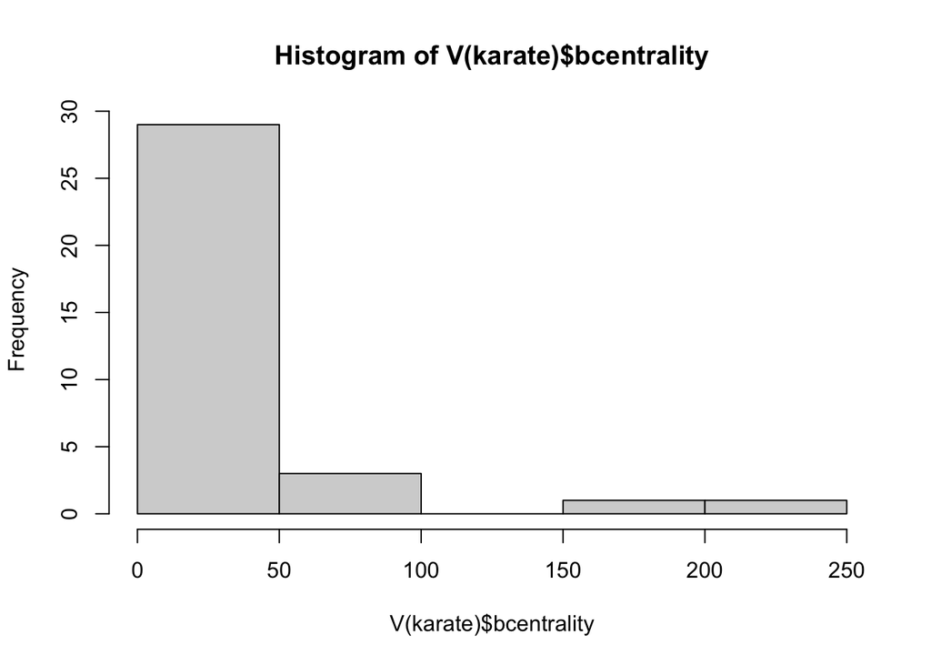

```r
#closeness(karate) # closeness centrality
#page_rank(karate)$vector # pagerank
#transitivity(karate, type = "local") # local clustering coefficient

# Visualisation
#
# Assign centrality score as attribute, example here is betweenness centrality
V(karate)$bcentrality <- betweenness(karate, directed=FALSE, weights=NA)
V(karate)$dcentrality <- degree(karate)
V(karate)$ccentrality <- closeness(karate)
V(karate)$pcentrality <- page_rank(karate)$vector

hist(V(karate)$bcentrality)
```

```r
# Normalise values to get a ranking
normalize <- function(x){(x-min(x))/(max(x)-min(x))} # min-max scaling brings everything to the interval [0,1]
V(karate)$bcentrality_index <- round(normalize(V(karate)$bcentrality)*9)+1 # this adjustment returns values between [1, 10]
V(karate)$bcentrality_index
```

```
##  [1] 10  2  4  1  1  2  2  1  2  1  1  1  1  2  1  1  1  1  1  2  1  1  1  1  1
## [26]  1  1  1  1  1  1  4  4  7
```

```r
# Map 10 colors to the 10 centrality-measure categories
V(karate)$bcolor_centrality <- colorRampPalette(c("steelblue", "gold","darkred"))(10)[V(karate)$bcentrality_index]

# Look at what we did
table(V(karate)$bcolor_centrality)
```

```
##
## #4682B4 #6F948C #8B0000 #C1BA3C #D88F00
##      23       6       1       3       1
```

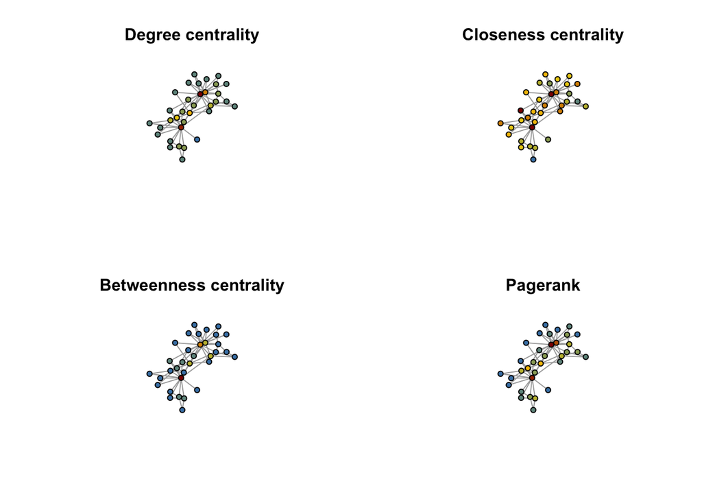

```r
# do it for the others, too
V(karate)$ccentrality_index <- round(normalize(V(karate)$ccentrality)*9)+1 # this adjustment returns values between [1, 10]
V(karate)$ccolor_centrality <- colorRampPalette(c("steelblue", "gold","darkred"))(10)[V(karate)$ccentrality_index] # Map 10 colors to the 10 centrality-measure categories

V(karate)$dcentrality_index <- round(normalize(V(karate)$dcentrality)*9)+1 # this adjustment returns values between [1, 10]
V(karate)$dcolor_centrality <- colorRampPalette(c("steelblue", "gold","darkred"))(10)[V(karate)$dcentrality_index] # Map 10 colors to the 10 centrality-measure categories

V(karate)$pcentrality_index <- round(normalize(V(karate)$pcentrality)*9)+1 # this adjustment returns values between [1, 10]
V(karate)$pcolor_centrality <- colorRampPalette(c("steelblue", "gold","darkred"))(10)[V(karate)$pcentrality_index] # Map 10 colors to the 10 centrality-measure categories

par(mfrow=c(2,2))

# plot
plot(karate,
     vertex.color = V(karate)$dcolor_centrality,
     vertex.label=NA,
     vertex.size=12,
     main='Degree centrality',
     layout = set_layout)

plot(karate,
     vertex.color = V(karate)$ccolor_centrality,
     vertex.label=NA,
     vertex.size=12,
     main='Closeness centrality',
     layout = set_layout)

plot(karate,
     vertex.color = V(karate)$bcolor_centrality,
     vertex.label=NA,
     vertex.size=12,
     main='Betweenness centrality',
     layout = set_layout)

plot(karate,
     vertex.color = V(karate)$pcolor_centrality,
     vertex.label=NA,
     vertex.size=12,
     main='Pagerank',
     layout = set_layout)
```

## Network thinking

This section aims at stimulating your network thinking. You will discover two network peculiarities that might appear counterintuitive at first glance, but make a lot of sense once you take the networks’ topologies into consideration.

### Majority illusion

In networks where we observe strong homophily, it might happen that we observe something like the “illusion of a majority”: Even if the majority does not hold a certain characteristic, we can draw a network in which most people believe the opposite is true.

To test for the majority illusion, we need to compare the average of the gender shares in all ego networks to the global gender share. Hence, we first have to iterate over all ego networks (one network per friend), remove the ego node for each ego network, and calculate the share of female friends a person “sees” in their ego network. Then, we need to average the perceived gender share among all nodes. In a second step, we need to calculate the gender shares in the friendship network from a global perspective.

Let’s extract an ego network for one person, for example, Amaya

```r
mtx_friends <- as.matrix(as_adj(g_undirected, sparse = igraph_opt("sparsematrices"))) # get out friendship matrix (the one we constructed ealier)
genders <- V(g_undirected)$gender
names <- V(g_undirected)$name

ego_networks <- sna::ego.extract(mtx_friends, ego = NULL, neighborhood = c("combined"))
friends_of_ego <- colnames(ego_networks$Amaya)[colnames(ego_networks$Amaya) != "Amaya"]

# get gender shares in ego network
prop.table(table(V(g_undirected)$gender[which(V(g_undirected)$name %in% friends_of_ego)]))
```

```
##
##    d    f    m
## 0.25 0.50 0.25
```

```r
# calculation of gender shares in terms of local averages
# ...
```

```r
# calculation of the gender shares from a global perspective
# ...
```

#### Exercise 1:

What do you observe? Why do you see what you see?

#### Exercise 2 (Extra): Reflections on the majority illusion

1. Which implications does this phenomenon, in your opinion, have for social cohesion? Or the “public opinion”? Political influence? …?
2. The majority illusion is only one peculiarity. Another stunning case, driven by homophily, that I want to bring to your attention is that even mild preferences often result in very strict homophilic patterns (along the lines of “the aggregate is more than the sum (of individual-level preferences)”). One of the most famous examples to illustrate this segregation (see work of Nobel Prize-winning game theorist Thomas Schelling, and especially his paper [Dynamic models of segregation](https://www.stat.berkeley.edu/~aldous/157/Papers/Schelling_Seg_Models.pdf) from 1971). You can play an interactive version of the paper content here: [Parable of Polygons](https://ncase.me/polygons/). Even if people are happy being in the minority, the group ends up being segregated. Comment: There is no network in this interactive post, but one could easily transfer this to a friendship network where people are allowed to rewire their connections.

#### Exercise 3: Blog posts

For this exercise, we will use some (a bit more exiting) real-world data. Precisely, the dataset from this [article](https://dl.acm.org/doi/pdf/10.1145/1134271.1134277?casa_token=4s9yFKDhE2oAAAAA:8k4b1uqozQwxn4DBIg0lDn9v0DnP07KxgYMyPYRtvmlwdf3i-8yMfpd41C74GAkFuGiRRKb9OYSuxw). The dataset contains front-page hyperlinks (edges) between blogs (nodes) in the context of the 2004 US election (directed network). The dataset is available [here](http://konect.cc/networks/moreno_blogs/).

1. Load the data (edges stored in `edges_blogs.txt`) and assign the labels (stored in `node_labels_blogs.txt`) to every node.
2. Repeat the steps as in Exercise 1. Do you find a majority illusion here, too?

```r
df1_graph <- read.table("./data/edges_blogs.txt", sep="\t", header=FALSE)
df2_nodes_attributes <- read.table("./data/node_labels_blogs.txt", sep="\t", header=FALSE)

colnames(df1_graph) <- c("node1", "node2")
colnames(df2_nodes_attributes) <- c("node", "attribute")


g_blogs <- graph_from_data_frame(df1_graph, directed=FALSE)
#g_blogs <- set_vertex_attr(G1, "leaning", index = V(G1), df2_nodes_attributes$attribute)
ecount(g_blogs)
```

```
## [1] 16715
```

```r
vcount(g_blogs)
```

```
## [1] 1224
```

```r
edge_density(g_blogs)
```

```
## [1] 0.02233205
```

```r
transitivity(g_blogs)
```

```
## [1] 0.2259585
```

```r
is_directed(g_blogs)
```

```
## [1] FALSE
```

```r
for (node in V(g_blogs)) {
  attribute <- df2_nodes_attributes[df2_nodes_attributes$node == node, "attribute"]
  g_blogs <- set_vertex_attr(graph = g_blogs, name = "leaning", index = node, value = as.character(attribute))
}

# average of the local perspectives
# ...

# global perspective
# ...
```

### The friendship paradox

#### Exercise 4:

It’s time for the next peculiarity of network effects: The friendship paradox.

For this exercise, we will use the data from the following [paper](https://dl.acm.org/doi/pdf/10.1145/1592665.1592675): Viswanath, B., Mislove, A., Cha, M., & Gummadi, K. P. (2009). On the evolution of user interaction in Facebook. Proceedings of the 2nd ACM Workshop on Online Social Networks, 37–42.

You can find it in the data folder under the name `data-facebook.txt`.

1. Read in the data, and construct your graph.
2. This time, we are not interested in the assortativity by age, but rather in assortativity by number of friends (i.e. the degree assortativity). Generate a plot that shows the average number of the friends of a person’s friends against the number of this person’s friends. Add the identity line (line that goes through (0,0) and (1,1)).
3. Persons above the identity line have fewer friends than their average neighbour, while nodes below the identity line have more. The friendship paradox states that most nodes have fewer friends than their friends’ average. Can you check whether the friendship paradox is also at play in the Facebook network? (Hint: One needs to count the number of nodes above and below the identity line and to compare the size of both groups.)
4. Calculate the degree assortativity.

```r
df2_graph <- read.table("./data/data_facebook.txt", sep=" ", header=FALSE)
colnames(df2_graph) <- c("node1", "node2")

g_facebook <- graph_from_data_frame(df2_graph, directed=FALSE)

vcount(g_facebook)
```

```
## [1] 63731
```

```r
ecount(g_facebook)
```

```
## [1] 817035
```

```r
# Get the degrees of the nodes
# ...

# calculate how many friends and ego's friends have on average
# ...

# Plot the data
# ...

# Count the number of nodes above and below the identity line
# ...

# Check for the friendship paradox
# ...
```